# 2020 Debate Transcripts

Daniel Zaltz

October 08, 2020

# Introduction

The debate transcripts are made available online through a variety of platforms. I have not searched for pre-processed data and instead make use of the `rvest` package to scrape data from https://www.rev.com/. For cleaning, I use a variety of functions from `dplyr` and `lubridate`. I am working backwards and so present a full description of how I gather and clean the data using the Vice Presidential debate. I repeat this with the first Presidential debate but with fewer comments.

# Data

## Vice Presidential Debate 10/7/2020

### Scrape data from web

```r
library(tidyverse) # will use a variety of wrangling/cleaning functions
library(rvest) # web scraping package

# read website data
url <- read_html("https://www.rev.com/blog/transcripts/kamala-harris-mike-pence-2020-vice-presidential-debate-transcript")

# extract relevant text from website
transcript_VP1 <- url %>%
  html_nodes("#transcription p") %>%
  html_text() %>%
  tibble()
```

*Note: I used the function `html_nodes()` to focus on the portion of the website that contains the text I want to extract. I use a point-and-click CSS selector as a Chrome extension, downloaded from https://selectorgadget.com/. The transcript is contained within the tag “#transcription p”.

### Examine raw data

The data is gathered into one column that includes the speaker, time stamp, and transcript.

```r
head(transcript_VP1)
```

```
## # A tibble: 6 x 1
##   .
##   <chr>
## 1 "Susan Page: (00:00)\nGood evening. From the University of Utah in Salt Lake ~
## 2 "Susan Page: (01:21)\nThese are tumultuous times, but we can and will have a ~
## 3 "Kamala Harris: (02:13)\nThank you, Susan. Well, the American people have wit~
## 4 "Kamala Harris: (03:21)\nCan you imagine if you knew on January 28th, as oppo~
## 5 "Susan Page: (04:17)\nThank you, Senator Harris-"
## 6 "Kamala Harris: (04:18)\n… right to reelection based on this."
```

### Split into relevant columns

First, I separate the speaker/time stamp from the actual transcript. This is fairly simple because the speaker and time stamp are separated from the text by a new line.

```r
transcript_VP1 <- transcript_VP1 %>%
  separate(
    1, # select first column (in this case, the only column)
    into = c("A", "transcript"), # separate into two columns (temporary names)
    sep = "\n" # separated by new lines, denoted via regex \n
  )

head(transcript_VP1)
```

```
## # A tibble: 6 x 2
##   A                  transcript
##   <chr>              <chr>
## 1 Susan Page: (00:0~ Good evening. From the University of Utah in Salt Lake Cit~
## 2 Susan Page: (01:2~ These are tumultuous times, but we can and will have a res~
## 3 Kamala Harris: (0~ Thank you, Susan. Well, the American people have witnessed~
## 4 Kamala Harris: (0~ Can you imagine if you knew on January 28th, as opposed to~
## 5 Susan Page: (04:1~ Thank you, Senator Harris-
## 6 Kamala Harris: (0~ … right to reelection based on this.
```

The transcript is now in its own column, but I have to split the speaker and time stamp. This will also be fairly simple because the speaker name is immediately followed by a colon before showing the time stamp.

```r
transcript_VP1 <- transcript_VP1 %>%
  separate(
    1, # select first column (which contains both speaker and time)
    into = c("speaker", "time"), # separate into new columns
    sep = ": " # separate by the colon after the speaker's name
  )

head(transcript_VP1)
```

```
## # A tibble: 6 x 3
##   speaker      time   transcript
##   <chr>        <chr>  <chr>
## 1 Susan Page   (00:0~ Good evening. From the University of Utah in Salt Lake Ci~
## 2 Susan Page   (01:2~ These are tumultuous times, but we can and will have a re~
## 3 Kamala Harr~ (02:1~ Thank you, Susan. Well, the American people have witnesse~
## 4 Kamala Harr~ (03:2~ Can you imagine if you knew on January 28th, as opposed t~
## 5 Susan Page   (04:1~ Thank you, Senator Harris-
## 6 Kamala Harr~ (04:1~ … right to reelection based on this.
```

We now have three columns, one for speaker, one for time, and one for the transcript.

### Clean the data

We should have three speakers (moderator, VP Pence, Senator Harris) and a continuous time, as there were no breaks in the debate.

First, check to see if we have three speakers. From the table we see that there are two different labels for Kamala Harris. There may be some extra spaces around her name, so we remove all extra space and re-evaluate. This works, and we now have three speakers.

```r
table(transcript_VP1$speaker)
```

```
##
##  Kamala Harris Kamala Harris      Mike Pence     Susan Page
##             43             51            114            119
```

```r
transcript_VP1$speaker <- str_squish(transcript_VP1$speaker)
table(transcript_VP1$speaker)
```

```
##
## Kamala Harris    Mike Pence    Susan Page
##            94           114           119
```

The speaker names are long. We can shorten them for easier manipulation later on.

```r
transcript_VP1 <- transcript_VP1 %>%
  mutate(
    speaker = case_when(speaker == "Kamala Harris" ~ "KH",
                        speaker == "Mike Pence" ~ "MP",
                        speaker == "Susan Page" ~ "moderator")
  )
```

Now on to the time stamps. These are currently stored as character strings. We may be interested in analyzing changes throughout the debate so we should create a more useful class of time stamps. Here is where I make use of the functions `lubridate::hms()` and its analogue `lubridate::ms()`. The functions convert character strings to hours:minutes:sec or just minutes:sec. I am not very familiar with these functions and ran into some issues at first – the `hms()` command gave me trouble when it was evaluating a time that only had minutes and seconds. To get around this, I implement a simple logical expression. If the time stamp has one colon it means there is just minutes:sec and therefore I will use the `ms()` function, but if it has two colons there must be hours:minutes:sec and I then use the `hms()` function. I would love some feedback on a way around this if there is one.

```r
transcript_VP1 <- transcript_VP1 %>%
  mutate(
    time = case_when(
      str_count(time, pattern = ":") == 1 ~ lubridate::ms(time),
      str_count(time, pattern = ":") == 2 ~ lubridate::hms(time))
  )
```

Now I check to see how we did when converting from character to time. The debate was one uninterrupted event and our time stamps should reflect this – I test this with a simple plot.

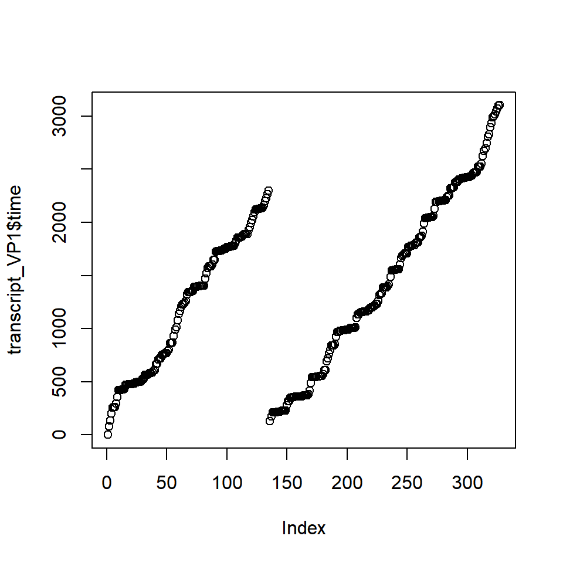

```r
plot(transcript_VP1$time)
```

Alas! Something has gone wrong. This should be one straight line. The x-axis shows the index (or row number) of where the time seems to restart from the beginning. From the graph this seems to occur somewhere around row 130. Let’s inspect.

```r
transcript_VP1[130:140,]
```

```
## # A tibble: 11 x 3
##    speaker   time     transcript
##    <chr>     <Period> <chr>
##  1 moderator 35M 36S  Senator Harris, as the vice president mentioned, you co-s~
##  2 KH        36M 2S   So, first of all, I will repeat and the American people k~
##  3 KH        36M 38S  And part of those jobs that will be created by Joe Biden ~
##  4 KH        37M 7S   And so Joe believes, again, in science. I’ll tell you som~
##  5 KH        37M 43S  So let’s talk about who is prepared to lead our country o~
##  6 moderator 38M 16S  Senator Harris just said that climate change is an existe~
##  7 MP        2M 9S    As I said, Susan, the climate is changing. We’ll follow t~
##  8 MP        2M 54S   And as USA TODAY said, it’s essentially the same plan as ~
##  9 moderator 3M 30S   Thank you.
## 10 MP        3M 30S   Joe Biden wants us to retrofit-
## 11 moderator 3M 32S   Thank you Vice President Pence.
```

As you can see, there is a break in time between rows 135 and 136. Why? I go back to the website and see that they divided their transcription into two parts, but the actual debate did not have any intermissions. We need to edit the time stamps. This takes a little bit of sleuthing:

1. The last time stamp from part 1 of the transcription is 38:16.
2. Re-watch the video that lines up with this part of the transcript. The moderator speaks for appx. 9s.
3. Pence responds immediately. This is the first item from part 2 of the transcript. The time stamp for his response is 02:09, but in reality it should be 00:09 (corresponding to 9s into part 2). Therefore, all time stamps in part 2 are off by 02:00.
4. We need to subtract 02:00 from all time stamps in part 2 and then re-add back the time that had already accrued in part 1 (38:16).
5. Therefore, to fully correct all time stamps from part two, we add an aggregate of 36:16.

```r
transcript_VP1$time[136:nrow(transcript_VP1)] <-
  transcript_VP1$time[136:nrow(transcript_VP1)] + lubridate::ms("36:16")
```

Check to see if the time appears to follow a continuous sequence.

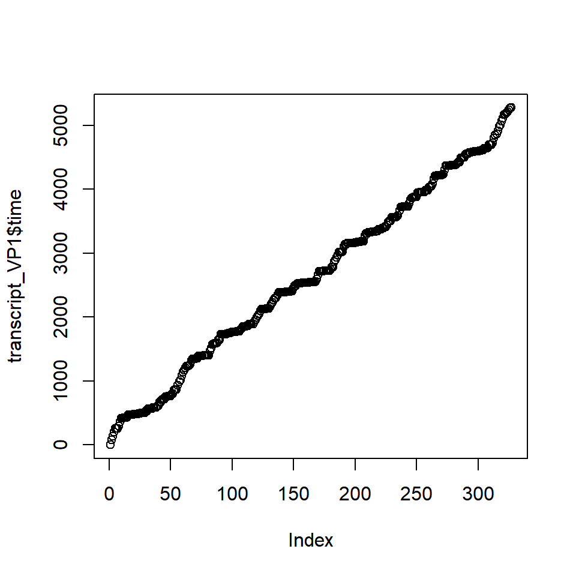

```r
plot(transcript_VP1$time)
```

Now, we inspect the time stamps, focusing on those surrounding this arbitrary part 1/2 divide.

```r
transcript_VP1$time[134:138]
```

```
## [1] "37M 43S" "38M 16S" "38M 25S" "38M 70S" "39M 46S"
```

Some of the seconds exceed 60. Oops. Let’s change this by using `roll = TRUE`.

```r
transcript_VP1$time <- lubridate::ms(transcript_VP1$time, roll = TRUE)
```

Upon further inspection things look good but I get an NA for the first time stamp, which should be 00:00. Add that manually.

```r
transcript_VP1$time[1] <- lubridate::ms("00:00")
head(transcript_VP1)
```

```
## # A tibble: 6 x 3
##   speaker   time    transcript
##   <chr>     <Perio> <chr>
## 1 moderator 0S      Good evening. From the University of Utah in Salt Lake City~
## 2 moderator 1M 21S  These are tumultuous times, but we can and will have a resp~
## 3 KH        2M 13S  Thank you, Susan. Well, the American people have witnessed ~
## 4 KH        3M 21S  Can you imagine if you knew on January 28th, as opposed to ~
## 5 moderator 4M 17S  Thank you, Senator Harris-
## 6 KH        4M 18S  … right to reelection based on this.
```

## Presidential Debate 9/29/2020

This follows a similar process as above and as such I have not included as much commentary. ### Scrape data from web

```r
url <- read_html("https://www.rev.com/blog/transcripts/donald-trump-joe-biden-1st-presidential-debate-transcript-2020")

transcript_P1 <- url %>%
  html_nodes("#transcription p") %>%
  html_text() %>%
  tibble()
```

### Examine raw data

Again we have arbitrary parts 1 and 2. In this transcript, there is a blank line at row 180.

```r
transcript_P1 <- transcript_P1[-180,] # remove blank line denoting the beginning of part 2
```

### Split into relevant columns

```r
transcript_P1 <- transcript_P1 %>%
  separate(
    1,
    into = c("A", "transcript"),
    sep = "\n"
  )
```

There is also no timestamp at the first row of part 2. Add that here.

```r
transcript_P1$A[180] <- "Chris Wallace: (00:00)"
```

Continue to split columns.

```r
transcript_P1 <- transcript_P1 %>%
  separate(
    1,
    into = c("speaker", "time"),
    sep = ": "
  )
```

### Clean the data

Rename variables and change time stamp class.

```r
transcript_P1 <- transcript_P1 %>%
  mutate(
    speaker = as.factor(case_when(speaker == "Chris Wallace" ~ "moderator",
                        speaker == "President Donald J. Trump" ~ "DT",
                        speaker == "Vice President Joe Biden" ~ "JB")),
    time = case_when(str_count(time, pattern = ":") == 1 ~ lubridate::ms(time),
                     str_count(time, pattern = ":") == 2 ~ lubridate::hms(time))
  )
```

Adjust part 2 time following similar method shown in prior section.

```r
transcript_P1$time[180:nrow(transcript_P1)] <-
  transcript_P1$time[180:nrow(transcript_P1)] + lubridate::ms("24:30")
head(transcript_P1)
```

```
## # A tibble: 6 x 3
##   speaker   time    transcript
##   <fct>     <Perio> <chr>
## 1 moderator 1M 20S  Good evening from the Health Education Campus of Case Weste~
## 2 moderator 2M 10S  This debate is being conducted under health and safety prot~
## 3 JB        2M 49S  How you doing, man?
## 4 DT        2M 51S  How are you doing?
## 5 JB        2M 51S  I’m well.
## 6 moderator 3M 11S  Gentlemen, a lot of people been waiting for this night, so ~
```

# Next steps

The data is now clean and ready for analysis. I have put a .csv of these data in `\data\clean`

A few ideas for descriptive analysis:

1. Total time spoken (calculate time per line using timestamps)
2. Total times interrupted (search for strings at end of lines that suggest this…no period?)
3. Most common words used
4. Sentiment analysis via `syuzhet` package?
5. Plot these by speaker/time?